# Activity 1: Introducing Bayesian Reasoning

Jingchen (Monika) Hu (Vassar) and Kevin Ross (Cal Poly), eCOTS 2022

# 1 Introduction

**This activity, which assumes no previous background in Bayesian statistics, will provide examples of how you can introduce Bayesian statistical reasoning in an introductory statistics class.** In Bayesian statistical analyses, uncertainty regarding population parameters is quantified by probability distributions, both before observing data (prior distribution) and after observing data (posterior distribution). This activity will contain examples illustrating, in the context of estimating a population proportion:

- How assessments of “relative plausibility” of parameters can be translated into probability distributions.
- How simulation can be used to approximate posterior distributions.
- How posterior distributions can be computed in tables/spreadsheets using the Bayesian paradigm: posterior is proportional to the product of prior and likelihood.
- How parameters can be estimated with credible intervals obtained from prior/posterior distributions.

## 1.1 Instructions

- Work on the activity together in your small groups.
- Each section in this document has multiple tabs.
  - First, think about and discuss the **Questions**. These questions are examples of questions that we would ask students.
  - Then read and discuss briefly the **Short solution**.
  - For later reference, slightly longer solutions with additional comments are provided in the **Discussion**.
  - Some **Code** is also provided for later reference. In the interest of time, we recommend that you don’t run the code or worry about syntax.
- **Ask questions of Kevin and Monika as you go!**

## 1.2 Notes

- In the interest of time we assume that workshop participants have some familiarity with:
  - named probability distributions (like Binomial, Normal)
  - simulation-based inference, such as using applets (e.g., RossmanChance, StatKey)
  - sampling distributions
  - the idea of a likelihood function and maximum likelihood
  - R
- But students only need minimal background in probability or statistics (e.g., probabilities must sum to 1), and no experience with coding is required.
- This activity is a compact version of how we would present this material in class. The exercises in this activity would be expanded and stretched out over several classes.
- When presenting to students, we would take a lot more time and care in introducing terminology and ideas than we have here. (We have included a few notes along the way.)

# 2 Setup

A [recent survey conducted by the Pew Research Center](https://www.pewresearch.org/science/2019/03/28/what-americans-know-about-science/) of American adults asked: “Based on what you have heard or read, which of the following two statements best describes the scientific method?”

- “The scientific method produces findings meant to be continually tested and updated over time”. (We’ll call this the “iterative” statement.)
- “The scientific method identifies unchanging core principles and truths”. (We’ll call this the “unchanging” statement.)
- Not sure which of the two statements is best.

Suppose we’re interested in **the proportion of current [*insert your college/university here*] students who agree with the iterative statement**. We’ll refer to this proportion as the “population proportion” and denote it as $\theta$ (the Greek letter “theta”). We will collect data on a sample of current students and use the sample data to make conclusions about $\theta$. In particular, given the sample data, what values are more or less plausible for $\theta$?

To illustrate ideas, we’ll start by considering only the values 0.1, 0.3, 0.5, 0.7, 0.9 as possible for the population proportion $\theta$. (Of course this is unrealistic; we’ll consider a more practical situation soon.) That is, we want to assess our relative plausibility of the statements:

- 10% of current students agree with the iterative statement
- 30% of current students agree with the iterative statement
- 50% of current students agree with the iterative statement
- 70% of current students agree with the iterative statement
- 90% of current students agree with the iterative statement

We’ll make an assessment before collecting sample data (the *prior distribution*), and then revise after we have observed some data (the *posterior distribution*).

# 3 Formulating a prior distribution

## 3.1 Questions

1. Before collecting data, which of these values — 0.1, 0.3, 0.5, 0.7, 0.9 — do you think is the least plausible for $\theta$?
2. Which value — 0.1, 0.3, 0.5, 0.7, 0.9 — do you think is the next least plausible? Roughly, how many *times* more plausible do you think it is than the one from the previous part?

   For example, suppose you think that 0.1 is the least plausible and 0.3 is the next least plausible value of $\theta$. If you think that 0.3 is 2 times more plausible than 0.1, then, roughly, you would be willing to engage in a bet that $\theta$ is 0.1 versus 0.3 at 2-to-1 odds.
3. Continue in the manner of the previous part to assign a relative plausibility to each of the values 0.1, 0.3, 0.5, 0.7, 0.9.
4. If 0.1, 0.3, 0.5, 0.7, 0.9 are the only possible values of $\theta$, then they should account for 100% of your total plausibility. Using your relative plausibilities from the previous part, what percent of your total plausibility does each of the values 0.1, 0.3, 0.5, 0.7, 0.9 represent? Make a table and a plot of your assessment.

## 3.2 Short solution

There are many reasonable responses to the previous questions. Your initial plausibility is whatever it is and reflects your background knowledge of this situation before collecting sample data. Different people will have different assessments — even within the same college/university — so there are many reasonable choices.

So that we’re all on the same page in what follows, suppose that before collecting sample data, our *prior* assessment of possible values of $\theta$, from least to most plausible, is that:

- 0.1 is least plausible
- 0.3 is 4 times more plausible than 0.1
- 0.5 is 3 times more plausible than 0.3
- 0.9 is 2 times more plausible than 0.5
- 0.7 is 1.5 times more plausible than 0.9

| theta | Prior “units” | Prior probability |
| --- | --- | --- |
| 0.1 | 1 | 0.0130 |
| 0.3 | 4 | 0.0519 |
| 0.5 | 12 | 0.1558 |
| 0.7 | 36 | 0.4675 |
| 0.9 | 24 | 0.3117 |
| Total | 77 | 1.0000 |

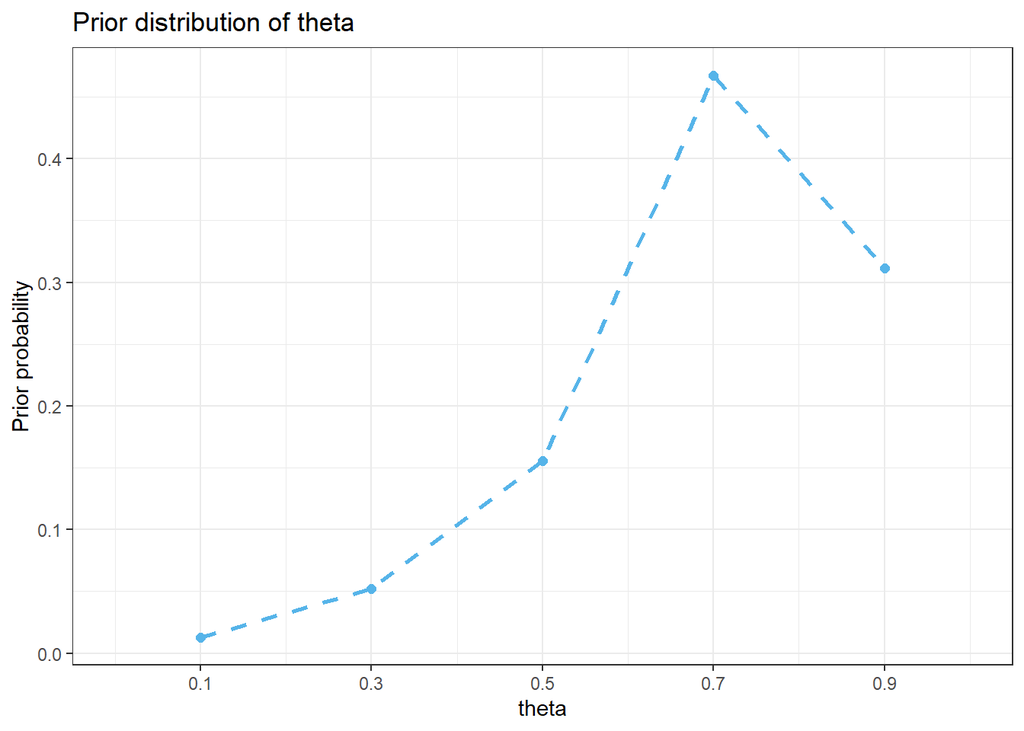

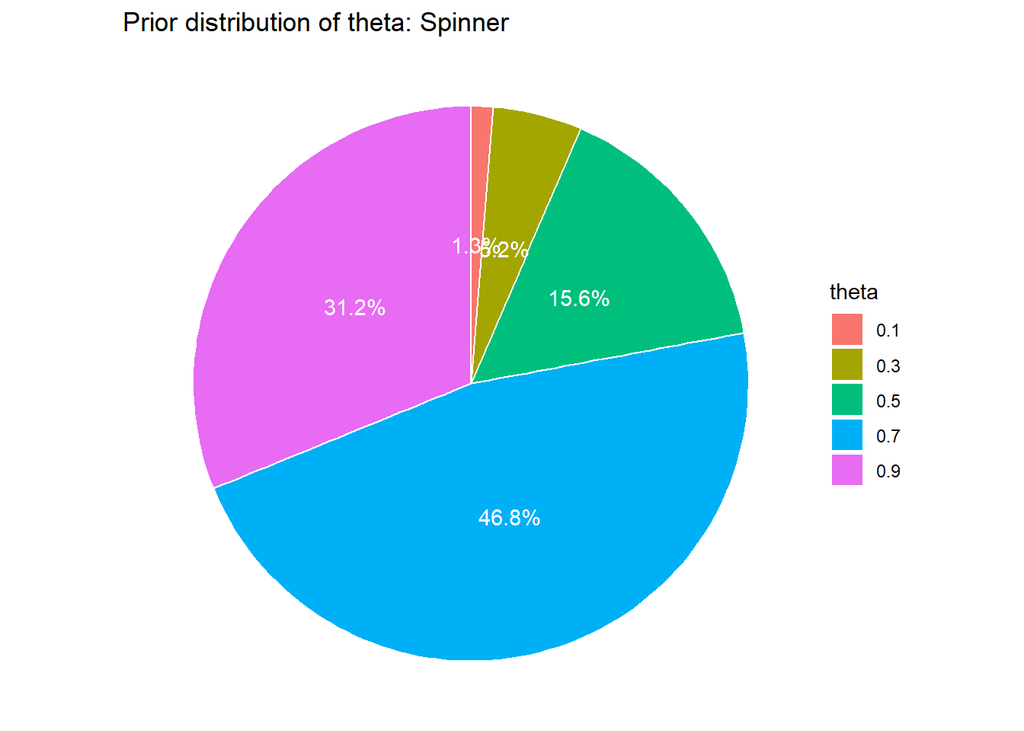

## 3.3 Discussion

There are many reasonable responses to the previous questions. Your initial plausibility is whatever it is and reflects your background knowledge of this situation before collecting sample data. Different people will have different assessments — even within the same college/university — so there are many reasonable choices.

So that we’re all on the same page in what follows, suppose that before collecting sample data, our *prior* assessment of possible values of $\theta$, from least to most plausible, is that:

- 0.1 is least plausible
- 0.3 is 4 times more plausible than 0.1
- 0.5 is 3 times more plausible than 0.3
- 0.9 is 2 times more plausible than 0.5
- 0.7 is 1.5 times more plausible than 0.9

The assessment above provides relative plausibilities. For example, is 0.1 has 1 “unit” of plausibility, then 0.3 has 4 units, 0.5 has 12 units, 0.9 has 24 units, and 0.7 has 36 units. Now we rescale the units to sum to 1 to represent 100% of our prior plausibility.

We could go into a little more detail about how we would calibrate 4 times versus 3 times, etc; for example, using [betting analogies](https://bookdown.org/kevin_davisross/bayesian-reasoning-and-methods/interpretations-of-probability.html#exm:subjective-bet). But the prior distribution doesn’t have to be perfect; there is no perfect prior distribution. We just need a relatively reasonable assessment of plausibility as our starting point. It’s our assessment after we have collected sample data that really matters. *We recommend against overemphasizing issues relating to choice of prior.*

## 3.4 Code

```r
library(tidyverse)
library(janitor)
library(viridis)
library(scales)

set.seed(21234)

bayes_col = c("#56B4E9", "#E69F00", "#009E73") # prior, likelihood, posterior
bayes_lty = c("dashed", "dotted", "solid") # prior, likelihood, posterior
```

The code below defines the prior distribution of $\theta$ and displays it in a table and plot.

```r
# Define the prior distribution

# Possible values of theta
theta = seq(0.1, 0.9, 0.2)

# Relative plausibilities, with least plausible as baseline of 1 unit
units = c(1, 4, 3 * 4, 1.5 * 2 * 3 * 4, 2 * 3 * 4)

# Rescale units to sum to 1
prior = units / sum(units)

prior_table = data.frame(theta,
                         units,
                         prior)

# Display prior distribution as a table

prior_table %>%
  adorn_totals("row") %>%
  kable(col.names = c("theta",
                      "Prior \"units\" ",
                      "Prior probability"),
        digits = 4)
```

| theta | Prior “units” | Prior probability |
| --- | --- | --- |
| 0.1 | 1 | 0.0130 |
| 0.3 | 4 | 0.0519 |
| 0.5 | 12 | 0.1558 |
| 0.7 | 36 | 0.4675 |
| 0.9 | 24 | 0.3117 |
| Total | 77 | 1.0000 |

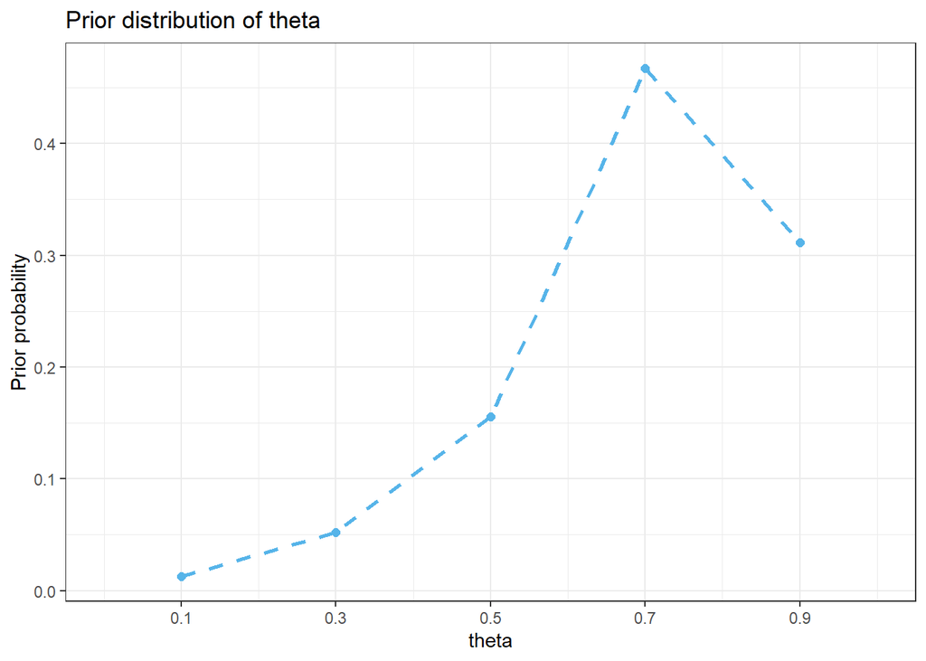

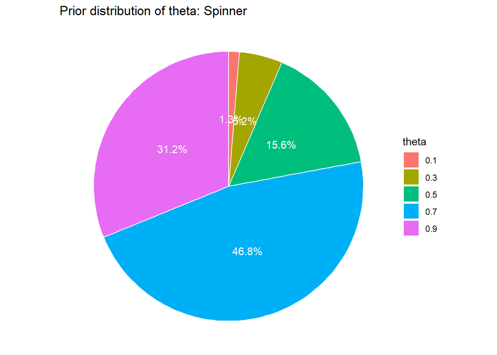

```r
# Display prior distribution in plots

# Plot of prior distribution

prior_table %>%
  ggplot(aes(x = theta,
             y = prior)) +
  geom_point(col = bayes_col[1], size = 2) +
  geom_line(linetype = "dashed", col = bayes_col[1], size = 1) +
  scale_x_continuous(limits = c(0, 1),
                     breaks = theta) +
  labs(title = "Prior distribution of theta",
       y = "Prior probability") +
  theme_bw()

# Pie chart "spinner" for prior distribution

prior_table %>%
  mutate(theta = factor(theta)) %>%
  ggplot(aes(x = "",
             y = -prior, # - for clockwise
             fill = theta)) +
  geom_bar(stat = "identity", color = "white") +
  coord_polar("y") +
  geom_text(aes(label = percent(prior)),
            position = position_stack(vjust = 0.5),
            color = "white") +
  labs(title = "Prior distribution of theta: Spinner") +
  theme_void()
```

# 4 Simulating potential samples given $\theta$

Now suppose we will survey $n = 25$ current students. Let $y$ denote the number of students in the sample who agree with the iterative statement. First we’ll use simulation to investigate what might happen.

## 4.1 Questions

1. If $\theta = 0.5$ what do you expect $y$ to be? Is this necessarily what we would see? If $\theta = 0.5$, how could we use simulation to approximate the distribution of $y$ over many possible samples? [Use this applet to conduct the simulation.](https://www.rossmanchance.com/applets/2021/oneprop/OneProp.htm) (*In the interest of time we are assuming some familiarity with simulation-based inference, but you could discuss this part and the idea of sampling distributions in more detail with students.* *With students, we would conduct some tactile simulations first.*)
2. Repeat the previous part for the other possible values of $\theta$, 0.1, 0.3, 0.7, 0.9. (Hint: click the “Show sliders” option below the plot.) Discuss what these plots tell us.

## 4.2 Short solution

The plot below displays the sampling distribution of $y$ for each of the possible values of $\theta$.

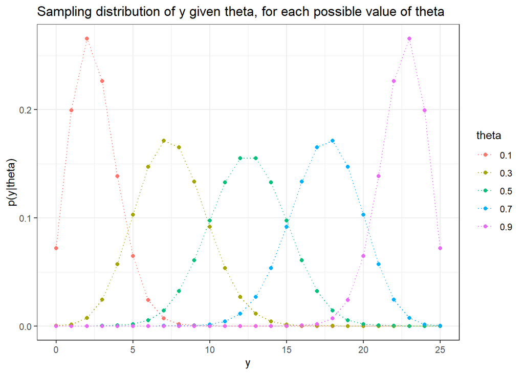

## 4.3 Discussion

For a given value of $\theta$ there is really nothing new beyond what students already learn in introductory statistics; students still need to understand ideas of sampling variability from frequentist statistics. Even if the population proportion $\theta$ is known, there is still natural sample-to-sample variability in $y$. Given a value of $\theta$, we can approximate the sample-to-sample distribution of $y$ by assuming the population proportion is $\theta$, simulating a sample of size 25 from this population, counting the number of “successes” in the sample, and repeating many times. This distribution depends on the value of the population proportion $\theta$; we get a different distribution for what might happen for each possible value of $\theta$. For example, if the population proportion is $\theta = 0.5$ then 13.28 percent of samples of size $n = 25$ yield $y = 14$ successes; if the population proportion is $\theta = 0.7$ then 5.36 percent of samples of size $n = 25$ yield $y = 14$ successes. If $\theta = 0.1$ we wouldn’t expect to see a sample with $y > 9$; if $\theta = 0.9$ we wouldn’t expect to see a sample with $y < 16$, etc.

## 4.4 Code

Rather than coding the simulation that the applet runs, we know that in this situation, given the value of $\theta$, $y$ has a Binomial(25, $\theta$) distribution. (*For students, we would just use the simulation results; we don’t need to introduce Binomial yet.*) The plot below displays the sampling distribution of $y$ for each of the possible values of $\theta$. When $\theta=0.1$ the distribution of $y$ is Binomial(25, 0.1); when $\theta=0.3$ the distribution of $y$ is Binomial(25, 0.3); etc.

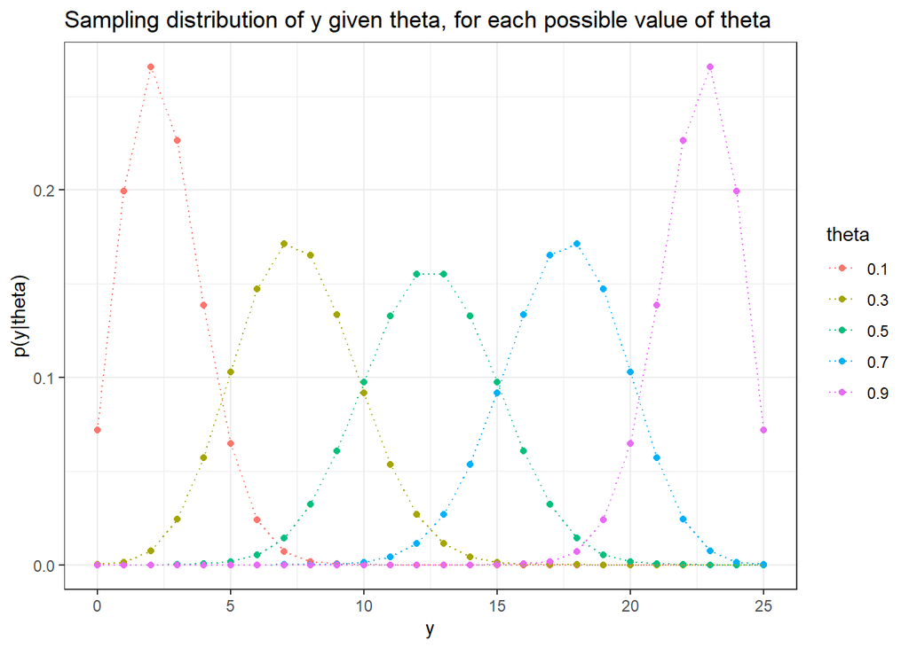

```r
n = 25

sampling_distribution_table = expand_grid(theta,
                                          y = 0:n) %>%
  mutate(prob = dbinom(y, n, theta))


sampling_distribution_table %>%
  mutate(theta = factor(theta)) %>%
  ggplot(aes(x = y,
             y = prob,
             col = theta)) +
  geom_point() +
  geom_line(linetype = "dotted") +
  labs(y = "p(y|theta)",
       title = "Sampling distribution of y given theta, for each possible value of theta") +
  theme_bw()
```

# 5 Reassessing plausibility

Recall our prior distribution from Section 3 (Short solution). After observing sample data we will reassess the relative plausibility of possible values of $\theta$. Let’s consider a few scenarios first.

## 5.1 Questions

1. If we observe $y = 18$, which value do you think is the most plausible value of $\theta$? Why?
2. If we observe $y = 15$, which value do you think is the most plausible value of $\theta$? Why?
3. If we observe $y = 14$, do you think that 0.5 is necessarily the most plausible value of $\theta$? Why?

## 5.2 Short solution

1. $y = 18$: $\theta = 0.7$ had highest prior plausibility, and has the highest likelihood of $y = 18$, so $\theta = 0.7$ has highest posterior plausibility
2. $y = 15$: $\theta = 0.7$ and $\theta = 0.5$ have roughly the same likelihood of $y = 15$, but $\theta = 0.7$ had the higher prior plausibility, so $\theta = 0.7$ has highest posterior plausibility
3. $y = 14$: $\theta = 0.7$ had highest prior plausibility, but $\theta = 0.5$ has the highest likelihood of $y = 14$, so it’s not obvious which will have the higher posterior plausibility.

We need a way to balance prior and likelihood.

## 5.3 Discussion

(*This discussion assumes some familiarity with the idea of a likelihood function and maximum likelihood.* *These ideas could be discussed in more detail with students.*)

1. Before observing any data, we assessed that 0.7 was the most plausible value of $\theta$. Now suppose we observe $y = 18$, for a sample proportion of $18 / 25 = 0.72$. The plot above shows that the likelihood of observing $y = 18$ is greatest when $\theta = 0.7$. In this sense, if $y = 18$ then $\theta = 0.7$ seems “most consistent” with the observed data. Since 0.7 was our most plausible value of $\theta$ prior to observing data, and $\theta = 0.7$ seems most consistent with the sample data, it seems that 0.7 should still be our most plausible value of $\theta$ after observing $y = 18$.
2. Now suppose we observe $y = 15$, for a sample proportion of $15 / 25 = 0.60$. The plot above shows that the likelihood of observing $y = 15$ is about the same when $\theta = 0.5$ as when $\theta = 0.7$, so $\theta = 0.5$ and $\theta = 0.7$ seem equally consistent with the sample data (and more consistent than the other $\theta$ values.) However, before observing data we assessed that 0.7 was a more plausible value of $\theta$ than 0.5. Therefore, we might still consider 0.7 as the most plausible value of $\theta$ after observing $y = 15$ (though our plausibility of 0.5 might be greater than it was prior to observing data.)
3. Now suppose we observe $y = 14$, for a sample proportion of $14 / 25 = 0.56$. The likelihood of observing $y = 14$ is greatest when $\theta = 0.5$. In this sense, if $y = 14$ then $\theta = 0.5$ seems “most consistent” with the observed data. However, before observing data we assessed that 0.7 was three times more plausible than 0.5 as a value of $\theta$. Also, the likelihood of observing $y = 14$ when $\theta = 0.7$ is not that small, though it is smaller than when $\theta = 0.5$. Therefore, if we observe $y = 14$ it’s not so obvious which value — 0.5 or 0.7 — is a more plausible value of $\theta$. We initially thought 0.7 was the most plausible value of $\theta$, and maybe a sample of size 25 with $y = 14$ is not enough data to convince us otherwise.

We need a way to balance our prior assessment with the observed sample data when reassessing plausibility of the possible values of $\theta$.

# 6 Revising our simulation to reflect prior plausibility

We simulated values of $y$ for each of the possible $\theta$ values, but the values of $\theta$ were not equally plausible.

## 6.1 Questions

1. How can we revise our simulation from before to reflect our prior assessment of plausible values of $\theta$? (*We start with this broad question, but students might need some additional prodding.*)
2. Conduct a few repetitions of this simulation and [enter your results in this Google sheet](https://docs.google.com/spreadsheets/d/1zkVgI9avf_rOYFi0CtTC1xeIcKw61srKGcPENDq9_hY/edit?usp=sharing). Just pick a row and enter your results. (You can use R: to simulate a value of $\theta$ from the prior distribution try `sample(seq(0.1, 0.9, 0.2), 1, replace = TRUE, prob = c(1, 4, 3 * 4, 1.5 * 2 * 3 * 4, 2 * 3 * 4))`, and use `rbinom(1, 25, [simulated theta])` to simulate $y$.)) (*With students, we would conduct some tactile simulations first and then use applets.*
3. View the plot of the simulation results in the Google sheet. (There are plots from a simulation with more repetitions in the Short solution.) There are two sources of uncertainty/variability in the simulation. What are they?

## 6.2 Short solution

First simulate a value of $\theta$ from the prior distribution, and given $\theta$, simulate $y$ as before.

Here are a few repetitions of the simulation.

[output not shown]

Here are some plots summarizing the simulation results. The plot on the left displays the $(\theta, y)$ pairs. The plot on the right displays the marginal distribution of $\theta$, which is (approximately) the prior distribution.

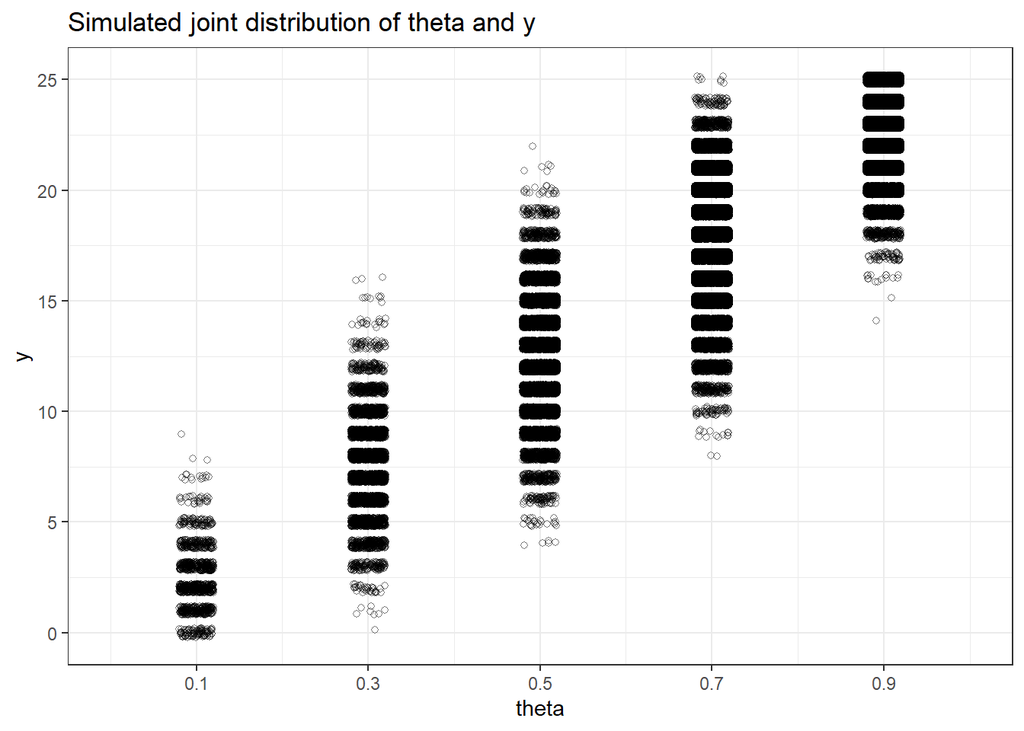

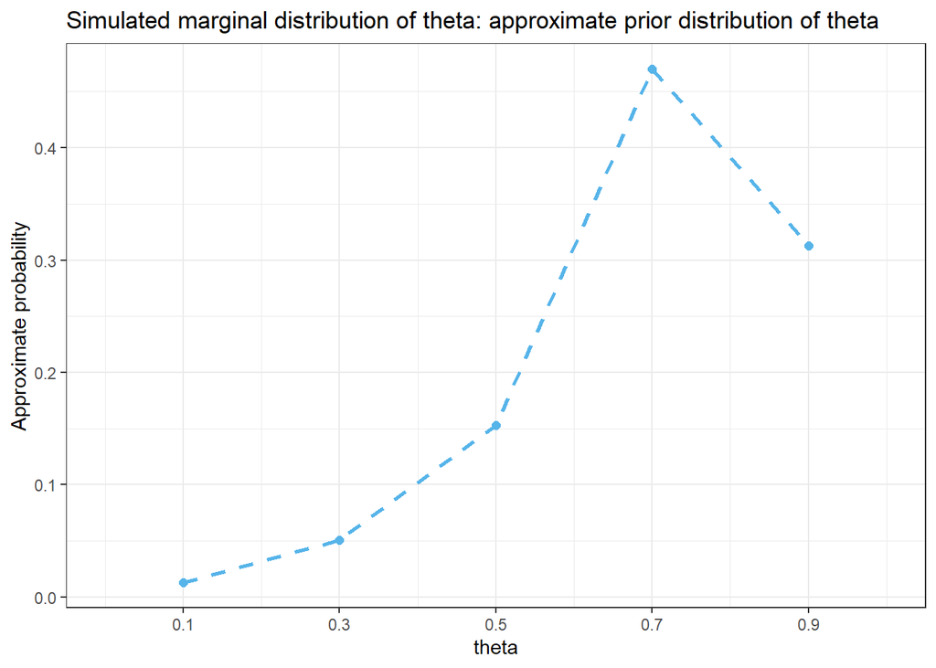

There are two sources or uncertainty/variability: sample-to-sample variability of $y$ (“old”), and uncertainty in $\theta$ represented by a probability distribution (“new”).

## 6.3 Discussion

We can account for the relative prior plausibility of values of $\theta$ by conducting a “weighted simulation”. Previously, we simulated many values of $y$ for each value of $\theta$. However, the values of $\theta$ are not equally plausible. For example, 0.7 is 36 times more plausible as a value of $\theta$ than 0.1. We want the simulation to give relatively more weight to more plausible values of $\theta$. Roughly, for every 1 repetition conducted using $\theta = 0.1$ we want to run 36 repetitions using $\theta = 0.7$.

We can conduct such a simulation in two stages as follows:

- Simulate a value of $\theta$ from its prior distribution (e.g., using a spinner like the one in the pie chart above that lands on 0.9 with probability 0.312, on 0.7 with probability 0.468, etc.) (*You can use `sample` in R with the `prob` argument, but with students we would use a tactile simulation or an applet.*)
- Given $\theta$, simulate a value of $y$ from a Binomial(25, $\theta$) distribution, like we did above. (*Again, students do not need Binomial distributions; they could describe a tactile simulation, or use an applet.*)
- Repeat many times and summarize the $(\theta, y)$ *pairs*.

There are two sources or uncertainty/variability in this simulation.

- For a given population proportion $\theta$, there is sample-to-sample variability in the sample count $y$.
  - This source of uncertainty should be familiar from frequentist statistics.
- There is uncertainty in the value of the population proportion $\theta$, represented by a probability distribution.
  - This is what’s “new” in Bayesian statistics.
  - We can quantify this uncertainty both before observing data (prior distribution) and, as we’ll do soon, after observing data (posterior distribution).

## 6.4 Code

Here is some code that runs the simulation, along with the results of a few repetitions.

```r
n_rep = 100000

# Simulate values of theta from the prior distribution
theta_sim = sample(theta, n_rep, replace = TRUE, prob = prior)

# For each simulated value of theta, simulate a value of y from Binomial(n, theta)
y_sim = rbinom(n_rep, n, theta_sim)

sim = data.frame(theta_sim,
                 y_sim)

# Display the (theta, y) results of a few repetitions
sim %>%
  head(10) %>%
  kable()
```

| theta_sim | y_sim |
| --- | --- |
| 0.7 | 18 |
| 0.7 | 18 |
| 0.7 | 21 |
| 0.7 | 19 |
| 0.1 | 2 |
| 0.5 | 12 |
| 0.5 | 11 |
| 0.9 | 22 |
| 0.5 | 14 |
| 0.3 | 13 |

Here are some plots summarizing the simulation results. The plot on the left displays the $(\theta, y)$ pairs. The plot on the right displays the marginal distribution of $\theta$, which is (approximately) the prior distribution.

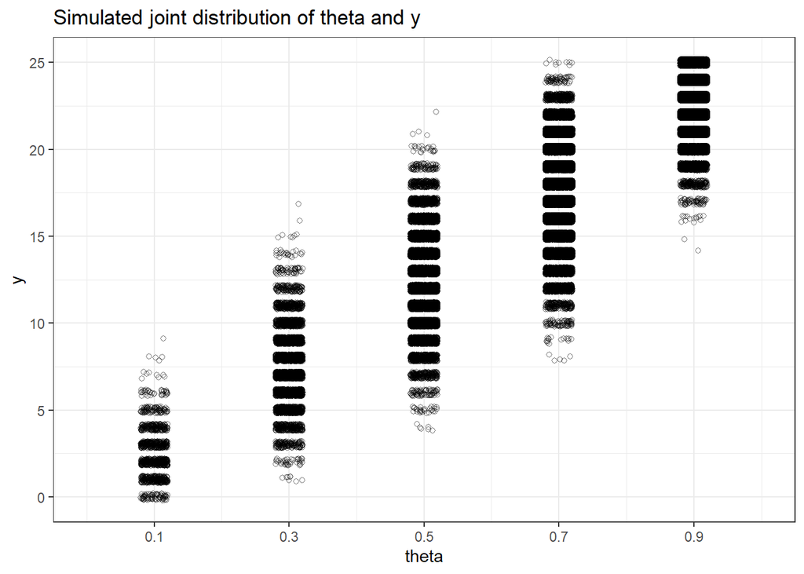

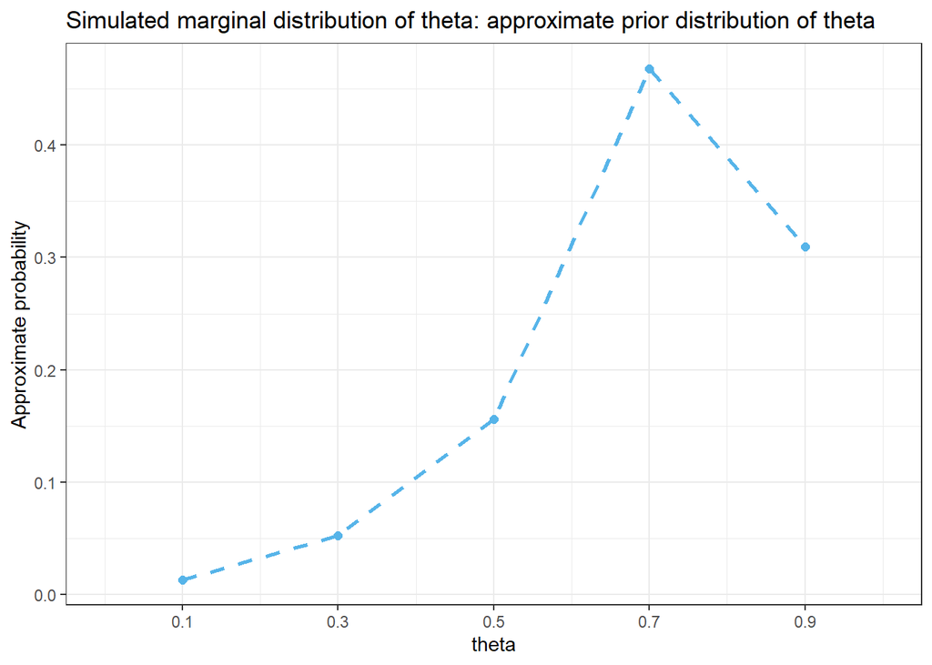

```r
# Plot the joint distribution of (theta, y) pairs
sim %>%
  ggplot(aes(x = theta_sim,
             y = y_sim)) +
  geom_jitter(width = 0.02, height = 0.2, shape = 21, alpha = 0.5) +
  scale_x_continuous(name = "theta",
                     limits = c(0, 1),
                     breaks = theta) +
  scale_y_continuous(name = "y",
                     breaks = seq(0, n, 5)) +
  labs(title = "Simulated joint distribution of theta and y") +
  theme_bw()

# Summarize the theta values and plot the marginal distribution of theta
sim %>%
  count(theta_sim, name = "freq") %>%
  mutate(rel_freq = freq / sum(freq)) %>%
  ggplot(aes(x = theta_sim,
             y = rel_freq)) +
  geom_point(col = bayes_col[1], size = 2) +
  geom_line(linetype = "dashed", col = bayes_col[1], size = 1) +
  scale_x_continuous(limits = c(0, 1),
                     breaks = theta) +
  labs(title = "Simulated marginal distribution of theta: approximate prior distribution of theta",
       y = "Approximate probability",
       x = "theta") +
  theme_bw()
```

# 7 Reassessing plausibility given sample data via simulation

So far we have considered what might happen when we collect sample data. But now let’s suppose we have actually collected data. In particular, suppose that we observe $y = 14$ students agreeing with the iterative statement in a sample of $n = 25$ students.

## 7.1 Questions

1. How might we use the results of the simulation in the previous section to reassess our plausibility of 0.1, 0.3, 0.5, 0.7, 0.9 as values of $\theta$ given the sample data? (*We start with this broad question, but students might need some additional prodding.*)
2. Use the plots from the previous section to (roughly) rank 0.1, 0.3, 0.5, 0.7, 0.9 from most to least plausible as values of $\theta$.

## 7.2 Short solution

The key to reassessing plausibility is to consider the **conditional distribution of $\theta$ given the sample data $y = 14$**. We can approximate this **posterior distribution** of $\theta$ by extracting the repetitions with $y = 14$ and summarizing the simulated values of $\theta$.

From the previous simulation results, we extract and summarize the $\theta$ values corresponding to $y = 14$.

| theta_sim | y_sim |
| --- | --- |
| 0.5 | 14 |
| 0.7 | 14 |
| 0.7 | 14 |
| 0.5 | 14 |
| 0.7 | 14 |
| 0.7 | 14 |
| 0.5 | 14 |
| 0.5 | 14 |
| 0.7 | 14 |
| 0.7 | 14 |

| theta | Simulated repetitions with y = 14 | Approximate posterior probability |
| --- | --- | --- |
| 0.3 | 23 | 0.0050 |
| 0.5 | 2036 | 0.4432 |
| 0.7 | 2534 | 0.5516 |
| 0.9 | 1 | 0.0002 |
| Total | 4594 | 1.0000 |

The plot on the left below is the simulated joint distribution of $(\theta, y)$ pairs from before, with repetitions with $y = 14$ highlighted. Slicing out this row and summarizing the $\theta$ values approximates the posterior distribution, displayed in the plot on the right.

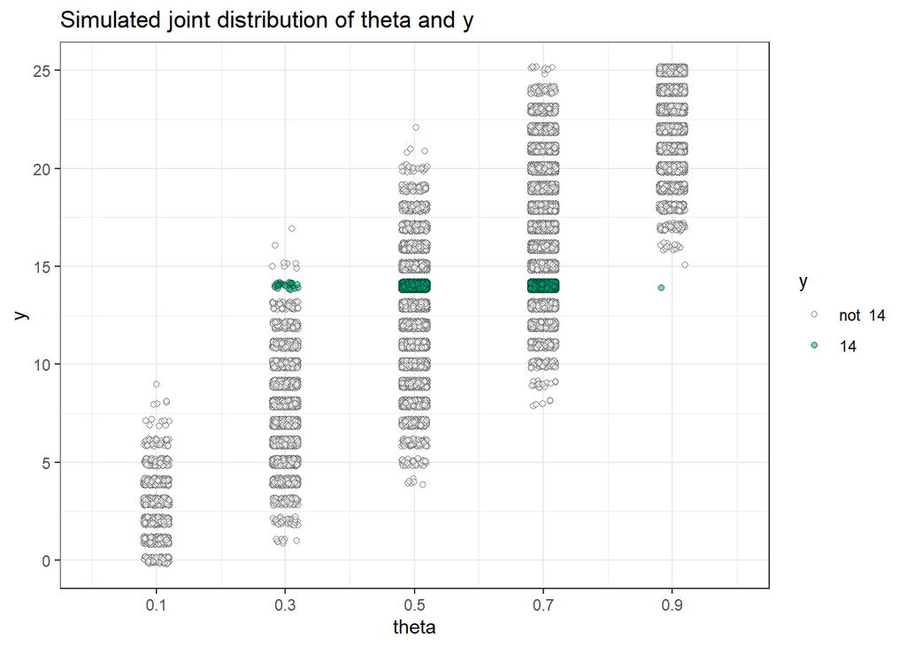

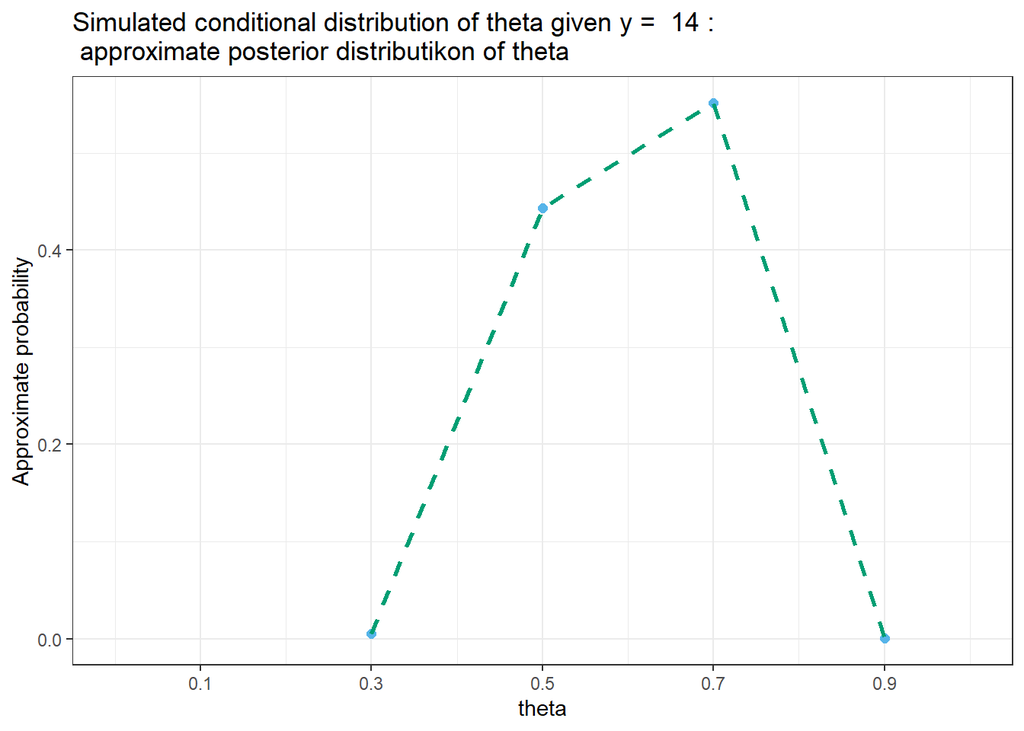

## 7.3 Discussion

The simulated marginal distribution of $\theta$ is based on all simulated values of $\theta$, and approximates the prior distribution. Given the observed $y = 14$, we zoom in on the simulated $\theta$ values corresponding to $y = 14$; what is the distribution of $\theta$ values among simulated repetitions with $y = 14$?

In the joint distribution plot above, focus on the row of dots corresponding to $(\theta, y)$ pairs with $y = 14$. Values of $\theta$ with relative more dots are relatively more plausible. Simulation suggests that 0.5 and 0.7 are the most plausible values of $\theta$ (it’s hard to tell which one is more plausible), followed by 0.3, while 0.1 and 0.9 have very little plausibility. Remember that this simulation reflects both our prior assessment of plausibility and the sample-to-sample variability of $y$. In this way, the posterior assessment is a compromise between prior and data/likelihood.

The key to reassessing plausibility is to consider the **conditional distribution of $\theta$ given the sample data $y = 14$**. We can approximate this **posterior distribution** of $\theta$ by extracting the repetitions with $y = 14$ and summarizing the simulated values of $\theta$.

## 7.4 Code

From the previous simulation results, we extract and summarize the $\theta$ values corresponding to $y = 14$.

```r
# Observed data
y_obs = 14

# Only keep simulated (theta, y) pairs with y = 14
sim %>%
  filter(y_sim == y_obs) %>%
  head(10) %>%
  kable()
```

| theta_sim | y_sim |
| --- | --- |
| 0.5 | 14 |
| 0.7 | 14 |
| 0.7 | 14 |
| 0.5 | 14 |
| 0.7 | 14 |
| 0.7 | 14 |
| 0.5 | 14 |
| 0.5 | 14 |
| 0.7 | 14 |
| 0.7 | 14 |

```r
# Only keep (theta, y) pairs with y = 14, and summarize the theta values
sim_posterior_table = sim %>%
  filter(y_sim == y_obs) %>% # condition on observed data
  count(theta_sim, name = "freq") %>%
  mutate(rel_freq = freq / sum(freq))

# Display the approximate posterior distribution in a table
sim_posterior_table %>%
  adorn_totals("row") %>%
  kable(col.names = c("theta",
                      paste("Simulated repetitions with y =", y_obs),
                      "Approximate posterior probability"),
        digits = 4)
```

| theta | Simulated repetitions with y = 14 | Approximate posterior probability |
| --- | --- | --- |
| 0.3 | 23 | 0.0050 |
| 0.5 | 2036 | 0.4432 |
| 0.7 | 2534 | 0.5516 |
| 0.9 | 1 | 0.0002 |
| Total | 4594 | 1.0000 |

The plot on the left below is the simulated joint distribution of $(\theta, y)$ pairs from before, with repetitions with $y = 14$ highlighted. Slicing out this row and summarizing the $\theta$ values approximates the posterior distribution, displayed in the plot on the right. The simulation suggests that, given $y=14$ successes, 0.7 and 0.5 account for almost all of our plausibility, and 0.7 remains the most plausible value of $\theta$. We’ll investigate the posterior distribution further below.

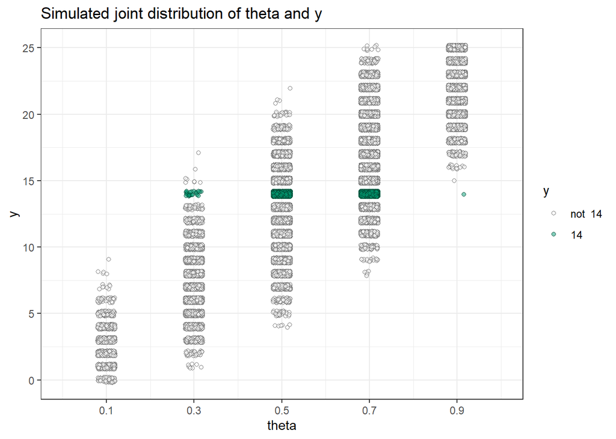

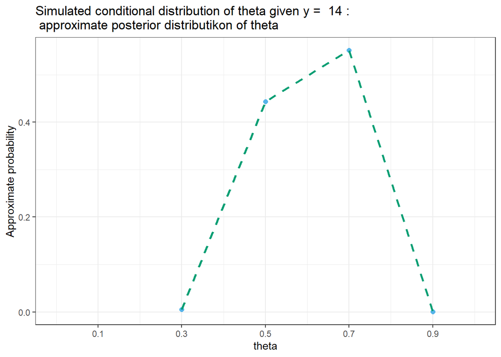

```r
# Plot the simulated (theta, y) pairs from before, with y = 14 highlighted
sim %>%
  mutate(given_y_obs = (y_sim == y_obs)) %>%
  ggplot(aes(x = theta_sim,
             y = y_sim,
             fill = given_y_obs)) +
  geom_jitter(width = 0.02, height = 0.2, shape = 21, alpha = 0.5) +
  scale_fill_manual(values = c("white", bayes_col[3]),
                    name = "y",
                    labels = c(paste("not ", y_obs), paste(y_obs))) +
  scale_x_continuous(name = "theta",
                     limits = c(0, 1),
                     breaks = theta) +
  scale_y_continuous(name = "y",
                     breaks = seq(0, n, 5)) +
  labs(title = "Simulated joint distribution of theta and y") +
  theme_bw()

# Plot the simulated conditional distribution of theta given y = 14
sim_posterior_table %>%
  ggplot(aes(x = theta_sim,
             y = rel_freq)) +
  geom_point(col = bayes_col[1], size = 2) +
  geom_line(linetype = "dashed", col = bayes_col[3], size = 1) +
  scale_x_continuous(limits = c(0, 1),
                     breaks = theta) +
  labs(title = paste("Simulated conditional distribution of theta given y = ", y_obs, ":\n approximate posterior distributikon of theta"),
       y = "Approximate probability",
       x = "theta") +
  theme_bw()
```

# 8 Posterior is proportional to the product of prior and likelihood

We have used simulation to approximate the posterior distribution of $\theta$ given $y = 14$. Now we will see how the posterior distribution can be derived from the prior distribution and the likelihood (which depends on the sample data).

## 8.1 Questions

1. Prior to observing data, how many times more plausible is 0.7 as the value of $\theta$ than 0.5?
2. How many times as likely is observing $y = 14$ when $\theta = 0.7$ than when $\theta = 0.5$? (*You can compute this using `dbinom`.* *We would have students use an applet, but they can also eyeball the ratio from the earlier plot with the sampling distributions.*)
3. After observing data, how many times more plausible is 0.7 as the value of $\theta$ than 0.5? (The simulated relative frequencies are approximations of the true posterior probabilities of 0.5447 for 0.7 and 0.4504 for 0.5.)
4. In what relatively simple way are the values in the previous three parts related? (Since simulated values are only approximations, if you based your ratios on simulated values you need to think in terms of $\approx$ rather than =. If you use the theoretical likelihoods (from `dbinom`) and posterior probabilities (provided), you can see an = relationship.)
5. Suggest a general principle for finding relative posterior plausibility of any two possible values of $\theta$ (like 0.7 and 0.5).
6. Given relative posterior plausibilities for all possible values of $\theta$, explain how you would find the posterior distribution? (Hint: remember how we found the prior distribution from relative prior plausibilities.)
7. Describe how you might compute the posterior distribution without using simulation. Think in terms of a spreadsheet; what are the rows? What are the necessary columns and how would you fill them in?

## 8.2 Short solution

1. Prior to observing data, we assumed that 0.7 was 3 times more plausible as the value of $\theta$ than 0.5.
2. The likelihood of $y = 14$ is 0.0536 when $\theta = 0.7$ and 0.1328 when $\theta = 0.5$, a ratio of 0.4031.
3. After observing data, 0.7 is 1.2 (= 0.5447 / 0.4504) times more plausible as the value of $\theta$ than 0.5.
4. Note that 1.2 = (3)(0.4).
5. **Posterior is proportional to the product of prior and likelihood**.
6. Rescale the values to sum to 1.
7. The posterior distribution can be computed in a spreadsheet form, sometimes called a “Bayes table”.
- There is one row for each possible value of $\theta$.
- There is a column for the prior distribution of $\theta$, containing the prior probability of each value of $\theta$.
- There is a column for the likelihood of the sample data computed for each possible value of $\theta$. In this example, we compute the likelihood of observing $y = 14$ from a Binomial(25, $\theta$) distribution for each value of $\theta$ (e.g., using `dbinom(14, 25, theta)`.)
- For each value of $\theta$, compute the product of prior and likelihood. This product column provides the relative posterior probabilities.
- Rescale the values in the product column to sum to 1 to obtain a column for the posterior distribution, containing the posterior probability of each value of $\theta$.

| theta | Prior probability | Likelihood of count of 14 | Product | Posterior probability |
| --- | --- | --- | --- | --- |
| 0.1 | 0.0130 | 0.0000 | 0.0000 | 0.0000 |
| 0.3 | 0.0519 | 0.0042 | 0.0002 | 0.0048 |
| 0.5 | 0.1558 | 0.1328 | 0.0207 | 0.4504 |
| 0.7 | 0.4675 | 0.0536 | 0.0250 | 0.5447 |
| 0.9 | 0.3117 | 0.0000 | 0.0000 | 0.0001 |
| Total | 1.0000 | 0.1906 | 0.0460 | 1.0000 |

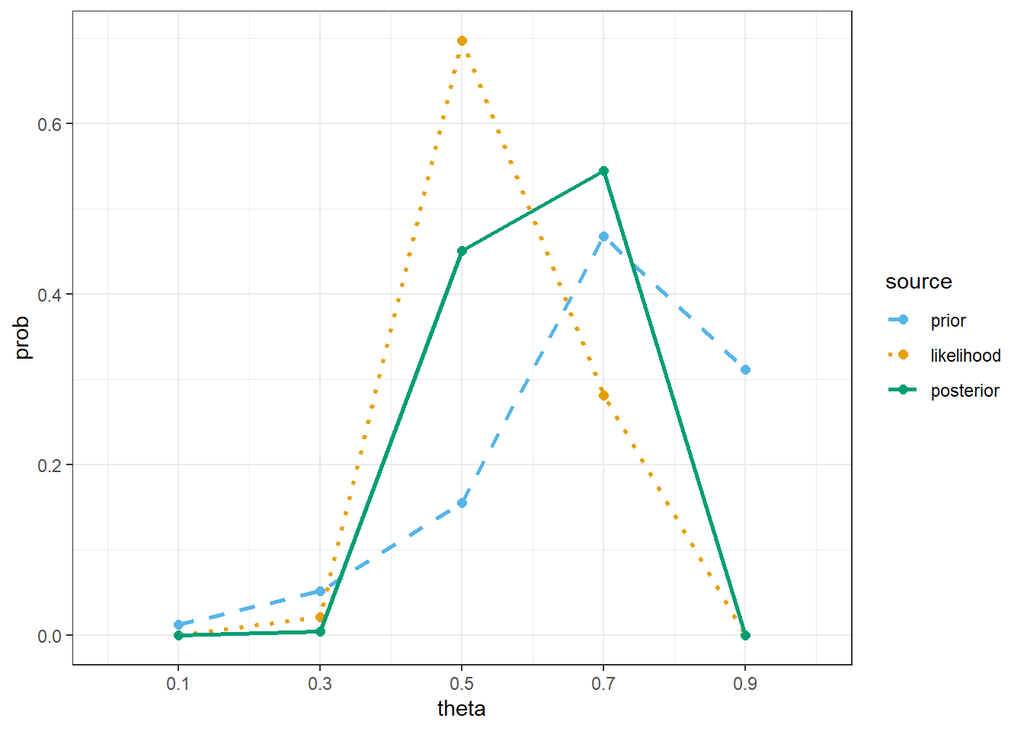

## 8.3 Discussion

1. Prior to observing data, we assumed that 0.7 was 3 times more plausible as the value of $\theta$ than 0.5.
2. The likelihood of $y = 14$ is 0.0536 when $\theta = 0.7$ and 0.1328 when $\theta = 0.5$, a ratio of 0.4031. Observing a sample with $y = 14$ is 0.4031 times as likely when $\theta = 0.7$ than when $\theta = 0.5$. (*With students we would spend more time on interpreting the likelihoods themselves: If the population proportion is $\theta = 0.5$ then 13.28 percent of samples of size $n = 25$ yield $y = 14$ successes; 2.5 times (1 / 0.4) as many samples of size $n = 25$ result in $y = 14$ successes when $\theta = 0.5$ than when $\theta = 0.7$.*)
3. After observing data, 0.7 is 1.2 (= 0.5447 / 0.4504) times more plausible as the value of $\theta$ than 0.5.
4. Note that 1.2 = (3)(0.4).
5. The ratio of the posterior probabilities is equal to the product of the ratio of the prior probabilities and the ratio of the likelihoods. That is, the posterior probability of a value of $\theta$ is proportional to the product of its prior probability and the likelihood of observing the sample data given the value of $\theta$. In short, **posterior is proportional to the product of prior and likelihood**.
6. As with the prior distribution, if we have relative plausibilities we simply need to rescale the values to sum to 1 to represent a probability distribution (accounting for 100% of plausibility).
7. The posterior distribution can be computed in a spreadsheet form, sometimes called a “Bayes table”.
- There is one row for each possible value of $\theta$.
- There is a column for the prior distribution of $\theta$, containing the prior probability of each value of $\theta$.
- There is a column for the likelihood of the sample data computed for each possible value of $\theta$. In this example, we compute the likelihood of observing $y = 14$ from a Binomial(25, $\theta$) distribution for each value of $\theta$ (e.g., using `dbinom(14, 25, theta)`.)
- For each value of $\theta$, compute the product of prior and likelihood. This product column provides the relative posterior probabilities.
- Rescale the values in the product column to sum to 1 to obtain a column for the posterior distribution, containing the posterior probability of each value of $\theta$.

## 8.4 Code

```r
n = 25

y_obs = 14

# Construct the Bayes table spreadsheet
# prior_table from before contains theta values and the prior distribution
# we add columns for likelihood, product, and posterior

bayes_table = prior_table %>%
  select(-units) %>%
  mutate(likelihood = dbinom(y_obs, n, theta), # depends on sample data
         product = prior * likelihood,
         posterior = product / sum(product))

# Display the Bayes table
bayes_table %>%
  adorn_totals("row") %>%
  kable(col.names = c("theta",
                      "Prior probability",
                      paste("Likelihood of count of ", y_obs),
                      "Product",
                      "Posterior probability"),
        digits = 4)
```

| theta | Prior probability | Likelihood of count of 14 | Product | Posterior probability |
| --- | --- | --- | --- | --- |
| 0.1 | 0.0130 | 0.0000 | 0.0000 | 0.0000 |
| 0.3 | 0.0519 | 0.0042 | 0.0002 | 0.0048 |
| 0.5 | 0.1558 | 0.1328 | 0.0207 | 0.4504 |
| 0.7 | 0.4675 | 0.0536 | 0.0250 | 0.5447 |
| 0.9 | 0.3117 | 0.0000 | 0.0000 | 0.0001 |
| Total | 1.0000 | 0.1906 | 0.0460 | 1.0000 |

The following plot displays the prior distribution, the likelihood function, and the posterior distribution. We see that the posterior distribution is a compromise between prior distribution and the likelihood. (The likelihood function is NOT a probability distribution and will not sum to anything in particular. However, in order to plot on a similar scale, the likelihood has been scaled to sum to 1.)

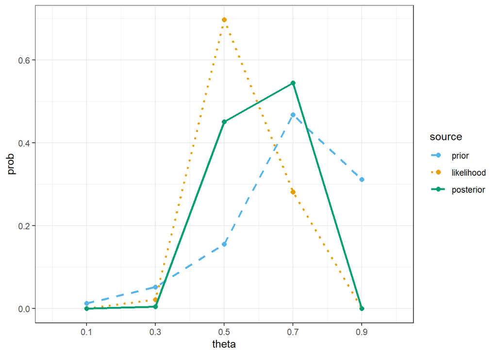

```r
bayes_table %>%
  mutate(likelihood = likelihood / sum(likelihood)) %>% # scale likelihood for plotting only
  select(-product) %>%
  pivot_longer(!theta,
               names_to = "source",
               values_to = "prob") %>%
  mutate(source = fct_relevel(source, "prior", "likelihood", "posterior")) %>%
  ggplot(aes(x = theta,
             y = prob,
             col = source)) +
  geom_point(size = 2) +
  geom_line(aes(linetype = source), size = 1) +
  scale_x_continuous(limits = c(0, 1),
                     breaks = theta) +
  scale_color_manual(values = bayes_col) +
  scale_linetype_manual(values = bayes_lty) +
  theme_bw()
```

# 9 A more realistic scenario

So far we have assumed that $\theta$ can only be 0.1, 0.3, 0.5, 0.7, 0.9. But in reality $\theta$ is a proportion which can take any value in [0, 1]. We will now consider prior and posterior distributions that assign plausibility to (almost) the full range of [0, 1] values.

## 9.1 Questions

1. Suppose our prior distribution for $\theta$ is (proportional to) a Normal distribution with mean 0.7 and standard deviation 0.15 (truncated to [0, 1]). Roughly, what does this distribution say about our prior assessment of plausibility? *We’re assuming that students are familiar with the 68-95-99.7 percent rule.* (We’ll investigate continuous distributions in more detail in following activities.)
2. We’ll continue to assume the same sample data as before: $n = 25$ and $y = 14$. We have seen two methods for computing/approximating a posterior distribution: simulation and spreadsheet/Bayes table. We will discuss simulation in more detail in following activities. For now, we’ll focus on spreadsheet/Bayes table. Describe how you would use a Bayes table to compute the posterior distribution of $\theta$ given $y = 14$. Hint: of course you can’t have one row for every value in [0, 1]; what seems like a reasonable approximation? (*We’re skipping straight to the full posterior distribution, but with students we suggest first doing a few calculations like the ones comparing 0.7 and 0.5 above.*)
3. The plot below displays the posterior distribution. Describe the posterior distribution. What are some questions you could use the posterior distribution to answer? What are some useful summary characteristics of the posterior distribution?
4. We will use the posterior distribution to obtain interval estimates of $\theta$. Compute and interpret a 68% posterior credible interval for $\theta$.
5. Compute and interpret a 95% credible interval for $\theta$.

## 9.2 Short solution

Grid approximation: possible values of $\theta$, 0, 0.0001, 0.0002, 0.0003, $\ldots$, 0.9998, 0.9999, 1. Selected rows of the Bayes table:

| theta | prior | likelihood | product | posterior |
| --- | --- | --- | --- | --- |
| 0.600 | 0.00021792 | 0.14650722 | 3.193e-05 | 0.00049986 |
| 0.625 | 0.00024017 | 0.12756919 | 3.064e-05 | 0.00047969 |
| 0.650 | 0.00025744 | 0.10342299 | 2.663e-05 | 0.00041686 |
| 0.675 | 0.00026839 | 0.07763390 | 2.084e-05 | 0.00032623 |
| 0.700 | 0.00027215 | 0.05355351 | 1.457e-05 | 0.00022818 |
| 0.725 | 0.00026839 | 0.03361037 | 9.020e-06 | 0.00014123 |
| 0.750 | 0.00025744 | 0.01893561 | 4.870e-06 | 0.00007632 |
| 0.775 | 0.00024017 | 0.00940401 | 2.260e-06 | 0.00003536 |
| 0.800 | 0.00021792 | 0.00401487 | 8.700e-07 | 0.00001370 |

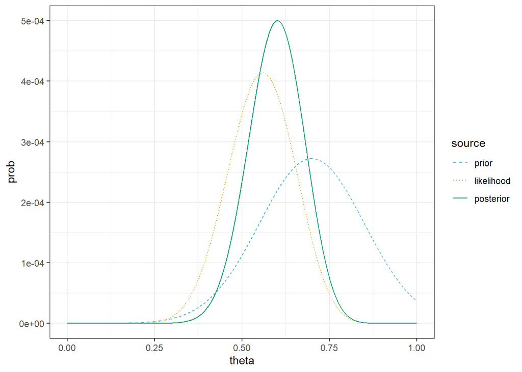

The posterior distribution of $\theta$ is approximately Normal with posterior mean 0.597 and posterior standard deviation 0.079.

A 68% posterior credible interval for $\theta$ is [0.518, 0.676]. There is a posterior probability of 68% that between 51.8 and 67.6 percent of current students agree with the iterative statement. It is roughly 2.1 times more plausible that the population proportion of current students who agree with the iterative statement lies inside the interval [0.518, 0.676] than outside.

## 9.3 Discussion

1. The Normal prior distribution suggests our “best guess” for $\theta$ is 0.7. The interval [0.55, 0.85] accounts for 68% of prior plausibility; before observing data it’s about 2.1 times more plausible that $\theta$ lies in the interval [0.55, 0.85] than outside. The interval [0.4, 1] accounts for 95% of prior plausibility; before observing data it’s about 19 times more plausible that $\theta$ lies above 0.4 than below.
2. We really want to assign plausibility to all values in the continuous interval [0, 1]. One way to bridge the gap is to consider a fine grid of values in [0, 1], rather than all possible values. We’ll consider the possible values of $\theta$ to be 0, 0.0001, 0.0002, 0.0003, $\ldots$, 0.9998, 0.9999, 1. The process for constructing a Bayes table works as before; it’s just a much longer table.
   - There is one row for each possible value of $\theta$: 0, 0.0001, 0.0002, 0.0003, $\ldots$, 0.9998, 0.9999, 1.
   - The prior column is filled in with the Normal(0.7, 0.15) density, `dnorm(theta, 0.7, 0.15)`, rescaled to sum to 1.
   - Since the sample data is the same as before, the computation of the likelihood has not changed — `dbinom(14, 25, theta)` — we’re just computing likelihood for many more values of $\theta$.
   - For each value of $\theta$, compute the product of prior and likelihood. This product column provides the relative posterior probabilities.
   - Rescale the values in the product column to sum to 1 to obtain a column for the posterior distribution, containing the posterior probability of each value of $\theta$.
3. Remember that the primary goal is to make conclusions about the population based on sample data. We can use the posterior distribution to formulate conclusions. The posterior distribution is approximately Normal. We might be interested in summary statistics like posterior mean or standard deviation. We might be interested in posterior probabilities or intervals. Here we just compute a few credible intervals. We will explore how to interpret and use the posterior distribution in the next activity.
4. The posterior distribution of $\theta$ is approximately Normal with posterior mean 0.597 and posterior standard deviation 0.079. We can use the 68-95 percent rule to compute credible intervals. (*Using the grid approximation, the posterior distribution of $\theta$ is discrete so we can computed mean and standard deviation using sums.* *We could also compute quantiles based on the discrete posterior, though the code is a little more complicated.* *Here, we use the 68-95 rule to compute credible intervals because it’s familar to students.* *Also, while grid approximation is a good way to introduce ideas, in practice simulation is almost always used to approximate the posterior distribution, so we don’t focus too much on computing based on discrete posterior distributions.*)

   A 68% posterior credible interval for $\theta$ is [0.518, 0.676]. There is a posterior probability of 68% that between 51.8 and 67.6 percent of current students agree with the iterative statement. It is roughly 2.1 times more plausible that the population proportion of current students who agree with the iterative statement lies inside the interval [0.518, 0.676] than outside.
5. A 95% posterior credible interval for $\theta$ is [0.439, 0.755]. There is a posterior probability of 95% that between 43.9 and 75.5 percent of current students agree with the iterative statement. It is roughly 19 times more plausible that the population proportion of current students who agree with the iterative statement lies inside the interval [0.439, 0.755] than outside.

## 9.4 Code

The code below constructs the Bayes table. Notice that the code is relatively short, and can be implemented in a spreadsheet. Only a few select rows of the table are displayed.

```r
# possible values of theta - grid approximation
theta = seq(0, 1, 0.0001)

# prior distribution
prior = dnorm(theta, 0.7, 0.15)

# rescale prior to sum to 1
prior = prior / sum(prior)

# sample data
n = 25
y = 14

# likelihood
likelihood = dbinom(y, n, theta)

# posterior
product = prior * likelihood
posterior = product / sum(product)


bayes_table = data.frame(theta,
                         prior,
                         likelihood,
                         product,
                         posterior)

# Display select rows of the Bayes table
bayes_table %>%
  slice(seq(6001, 8001, 250)) %>% # selects a few rows to display
  kable(digits = 8)
```

| theta | prior | likelihood | product | posterior |
| --- | --- | --- | --- | --- |
| 0.600 | 0.00021792 | 0.14650722 | 3.193e-05 | 0.00049986 |
| 0.625 | 0.00024017 | 0.12756919 | 3.064e-05 | 0.00047969 |
| 0.650 | 0.00025744 | 0.10342299 | 2.663e-05 | 0.00041686 |
| 0.675 | 0.00026839 | 0.07763390 | 2.084e-05 | 0.00032623 |
| 0.700 | 0.00027215 | 0.05355351 | 1.457e-05 | 0.00022818 |
| 0.725 | 0.00026839 | 0.03361037 | 9.020e-06 | 0.00014123 |
| 0.750 | 0.00025744 | 0.01893561 | 4.870e-06 | 0.00007632 |
| 0.775 | 0.00024017 | 0.00940401 | 2.260e-06 | 0.00003536 |
| 0.800 | 0.00021792 | 0.00401487 | 8.700e-07 | 0.00001370 |

The following plot displays the prior distribution, the likelihood function, and the posterior distribution. We see that the posterior distribution is a compromise between prior distribution and the likelihood. (The likelihood function is NOT a probability distribution and will not sum to anything in particular. However, in order to plot on a similar scale, the likelihood has been scaled to sum to 1.)

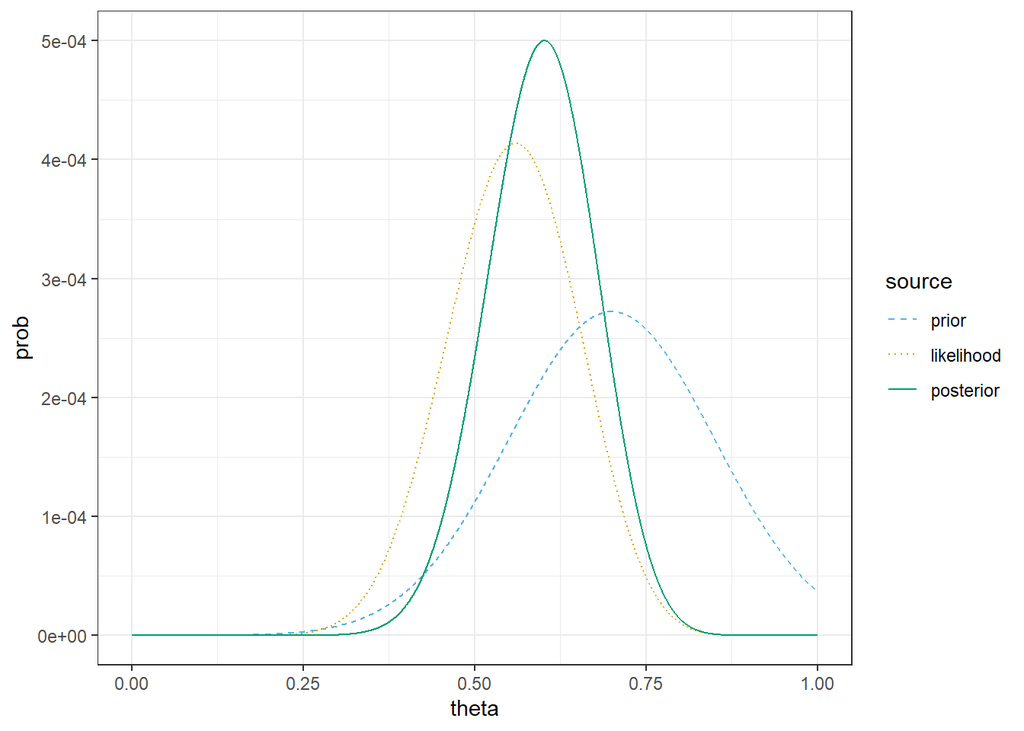

```r
bayes_table %>%
  mutate(likelihood = likelihood / sum(likelihood)) %>% # scale likelihood for plotting only
  select(-product) %>%
  pivot_longer(!theta,
               names_to = "source",
               values_to = "prob") %>%
  mutate(source = fct_relevel(source, "prior", "likelihood", "posterior")) %>%
  ggplot(aes(x = theta,
             y = prob,
             col = source)) +
  geom_line(aes(linetype = source)) +
  scale_color_manual(values = bayes_col) +
  scale_linetype_manual(values = bayes_lty) +
  theme_bw()
```

Here we compute the posterior mean and standard deviation based on formulas for a discrete distribution, but typically we would just use `mean` and `sd` on values of $\theta$ simulated from the posterior distribution.

```r
posterior_mean = sum(theta * posterior)

posterior_sd = sqrt(sum(theta ^ 2 * posterior) - posterior_mean ^ 2)

posterior_mean; posterior_sd
```

```
## [1] 0.597132
```

```
## [1] 0.07872458
```

# 10 Wrap up

## 10.1 Summary

- In Bayesian statistical analyses, parameters are treated as random variables with prior/posterior probability distributions that quantify our degree of uncertainty or plausibility about parameters before/after observing data.
- The posterior distribution is the conditional distribution of parameters given the observed data
- We update distributions a relatively simple formula: posterior is proportional to the product of prior and likelihood
- Computation of the posterior distribution can be illustrated in relatively simple spreadsheets.
- Posterior distributions can be (and usually are) approximated with simulation
- Parameters can be estimated with credible intervals based obtained from prior/posterior distributions.

## 10.2 Comments

- Activities like these can be used with students with little to no background in probability or statistics.
- Bayesian statistics does not necessarily involve more math than frequentist statistics.
- Can teach Bayesian statistics using a Simulation-based approach.
- The Bayesian approach is natural for many students, especially in comparison with null hypothesis testing.
- Bayesian analyses are inherently multivariable (because parameters are variables), giving students lots of experience with multivariable thinking (a GAISE guideline).
- Students, especially students with little background in statistics, often have less hesitation to using Bayesian statistics than their teachers do!
- Choice of prior is just one assumption. Don’t spend too much time on choosing the prior. It’s the posterior that matters!
- One common criticism of the Bayesian paradigm is that it rests on a subjective interpretation of probability, which seems (at first glance anyway) to lack the principle of objectivity on which science prides itself. However, any statistical analysis is inherently subjective, filled with many assumptions and decisions along the way. Subjectivity is OK, and often beneficial, allowing us to explicitly incorporate a wealth of past experience into our analysis.
- Remember, Bayesian statistics is statistics. The same best practices that you use in other classes still apply. In particular, focus on conceptual understanding rather than calculus, computation, or coding.
- While there is some code provided, the core components of finding the posterior distribution via simulation or grid approximation can be done with simple code or spreadsheets. (Most of the longer code is for summarizing or plotting.)
- Students need not be required to write or run code. Especially when first introducing Bayesian ideas, we provide students with any code or output, and focus their attention on describing the process and interpreting output.

## 10.3 Further questions to investigate with students

- How does the posterior compare to the prior?
- Which values are more/less plausible according to the posterior than the prior?
- How does changing the prior influence the posterior?
- How sensitive is the posterior to choice of prior?
- How does changing the sample proportion influence the posterior?
- How does changing the sample size influence in the posterior?
- How do we summarize the posterior distribution?
- How does the mean of the posterior distribution relate to the mean of the prior distribution and the observed sample proportion?
- How do we interpret the posterior standard deviation?
- How plausible is it that more than [blank] percent of students agree with the iterative statement?
- How do the results at our college/university compare to the results from the Pew Research Survey?
- Be sure to also include plenty of “usual” statistics questions like: How was the sample selected? How were the variables measured? Are there any potential, important sources of bias?
- Depending on the class, we might also compare our Bayesian analysis to a frequentist analysis, both in terms of numerical results and interpretation.

## 10.4 Resources

- Kevin’s notes: [*An Introduction to Bayesian Reasoning and Methods*](https://bookdown.org/kevin_davisross/bayesian-reasoning-and-methods/)
- Monika’s book with Jim Albert: [*Probability and Bayesian Modeling*](https://bayesball.github.io/BOOK/probability-a-measurement-of-uncertainty.html)
- JSDSE paper [“Teaching an Undergraduate Course in Bayesian Statistics: A Panel Discussion”](https://doi.org/10.1080/10691898.2020.1845499)